# Guía 7 Inferencia estadística

Curso Introducción al Análisis de datos con R para la acuicultura

Dr. José A. Gallardo y Dra. María Angélica Rueda.

Pontificia Universidad Católica de Valparaíso  
jose.gallardo@pucv.cl

12 July 2021

#### **Introducción**

**Parámetros y estadísticos**

Parámetro: Constante que caracteriza a todos los elementos de un conjunto de datos de una población. Se representan con letras griegas.

Promedio de una población = $\mu$ (mu).

Estadístico: Una función de una muestra aleatoria o subconjunto de datos de una población.

**Promedio de una muestra**:
$$\bar{X} = \frac{\sum_{i=1}^{n} x_{i}}{n}$$

**Varianza de una muestra**:
$$s^{2} = \frac{SS}{N - 1} = \frac{\sum (x_{i} - \bar{x})^{2}}{N - 1}$$

**Correlación entre x e y**:
$$r = \frac {{SS}_{xy}}{\sqrt {{SS}_{xx}{SS}_{yy}}}$$

donde,
$${SS}_{xx} = \sum (x - \bar{x})^2 = \sum x^2 - \frac {(\sum x)^2}{n}$$
$${SS}_{xy} = \sum (x - \bar{x})(y - \bar{y}) = \sum xy - \frac {(\sum x)(\sum y)}{n}$$
**Inferencia estadística**

Corresponde a la aplicación de diferentes métodos que permiten obtener o extraer conclusiones sobre los parámetros de una población a partir de una muestra de datos tomada en ella. También, es posible calcular el grado de fiabilidad (probabilidad) de que los resultados extraídos de un estudio son verdaderos o falsos.

**Estimación v/s pruebas de hipótesis**

Estimación: Se utiliza para **“estimar”** parámetros de una población a partir de una muestra de una variable aleatoria.

Ejemplo: Estimar el promedio del peso del cuerpo de la población a partir de una muestra de 30 animales.

Pruebas de hipótesis: Se utiliza para realizar una afirmación acerca del valor de un parámetro, usualmente contrastando con una hipótesis.

Ejemplo: Probar que el peso promedio del cuerpo de un grupo de peces es mayor si son alimentados con la dieta A en vez de la dieta B.

**Estimación puntual v/s por intervalo**

Estimación puntual: consiste en asumir que el parámetro tiene el mismo valor que el estadístico en la muestra.

Estimación por intervalos: se asigna al parámetro un conjunto de posibles valores que están comprendidos en un intervalo asociado a una cierta probabilidad de ocurrencia.

**Hipótesis nula v/s hipótesis alternativa**

Hipótesis nula (**H<sub>0</sub>**): Es una hipótesis que el investigador trata de refutar, rechazar o anular. Se le denomina “nula” porque se expresa como la igualdad entre dos grupos.

Hipótesis alternativa (**H<sub>1</sub>**): Es lo que el investigador realmente piensa que es verdadero.

#### **Objetivos de aprendizaje**

Los objetivos de aprendizaje de esta guía son:

**1**. - Elaborar hipótesis estadísticas.

**2**. - Realizar análisis de inferencia estadística para comparación de datos cuantitativos continuos.

**3**. - Elaborar un reporte dinámico en formato pdf con **[Rmarkdown](https://rmarkdown.rstudio.com/)**.

#### Librerías

| **Librería** | **Función** |
| --- | --- |
| **ggplot2** | Permite la visualización de datos, es usado para realizar gráficas avanzadas con R *Hoja de referencia*. |
| **psych** | Permite realizar histogramas y correlaciones de datos en formato de matriz. |
| **readxl** | Permite importar datos desde archivos con formato .xls y .xlsx. |
| **stats** | Posee funciones para hacer las pruebas de hipótesis para la media y diferencia de medias (con muestras independientes). También, para hacer la prueba de hipótesis de correlación. |
| **pander** | Muestra en formato tabla los resultados de un objeto. |

#### **Comandos**

A continuación, se presentan algunos comandos que deberá usar para resolver los ejercicios de esta guía.

**1.-** Visualiza la variación de tus datos de forma avanzada con: **ggplot()**

**2.-** Realiza la correlación lineal entre x e y: **cor(x,y)**

**3.-** Realiza la prueba de hipótesis para la correlación entre x e y: **cor.test()**

**4.-** Extrae los intervalos de confianza para la correlación: **cor.test()$conf.int**

**5.-** Calcula la media **mean()** y la varianza **var()** de la variable en estudio.

**6.-** Realiza la prueba de hipótesis para la media y diferencia de medias (con muestras independientes): **t.test()**

**7.-** Extrae los intervalos de confianza para la media y diferencia de medias (con muestras independientes): **t.test()$conf.int**

**8.-** Muestra en formato de tabla los resultados de las pruebas de hipótesis: **pander()**

### **Ejercicio 1.** **Elaborar archivo Rmarkdown**

Usando lo aprendido en la unidad 1 del curso elabore y configure un archivo o file con extensión **.Rmd** y configúrelo para exportar el resultado como un documento dinámico **pdf**.

Utilice el siguiente ejemplo para completar la información del metadatos: Título: Reporte inferencia estadística, nombre del autor: Su nombre.

Luego guarde inmediatamente su *script* como **script_6_nombre_apellido.Rmd**. Al finalizar la actividad deberá exportar y almacenar este script en su carpeta drive de tareas.

### **Ejercicio 2.** **Configuración del reporte**

En el primer bloque de códigos o **chunk** configure los comandos de la siguiente manera *knitr::opts_chunk$set(echo = TRUE)* y cargue las librerías **stats**, **graphics**, **ggplot2**, **psych**, **readxl**, **pander**, **dplyr** y **knitr**.

```r
knitr::opts_chunk$set(echo = TRUE)

# Librería stats está instalada por defecto en la base de R
library(stats)

# Librería graphics está instalada por defecto en la base de R
library(graphics)

# Librería psych para análisis de datos de matrices
library(psych)

# Librería para gráficas avanzadas
library(ggplot2)

# Librería para importar datos
library(readxl)

# Librería para mostrar en formato tabla los resultados de un objeto
library(pander)

# Librería para usar funciones de tidyverse
library(dplyr)

# Librería para hacer tablas
library(knitr)
```

Ejecute cada uno de los siguientes ejercicios en uno o más bloques de códigos diferentes. Sea ordenado y documente su reporte adecuadamente.

### **Ejercicio 3.** **Prueba de hipótesis de correlación**

Los datos **Tilapia_data.xlsx** se refieren a la longitud (**Longitud_cm**) y el peso (**Peso_g**) de 100 tilapias machos de cultivos provenientes del Ecuador.

**a).** Importe el set de datos **Tilapia_data.xlsx** usando la función **read_excel()** de la librería **readxl**, llame al objeto Tilapia. Explore el set de datos usando las funciones **head()**, **str()** y **summary()**.

```r
Tilapia <- read_excel("Tilapia_data.xlsx")
head(Tilapia)
```

```
## # A tibble: 6 x 3
##      ID Longitud_cm Peso_g
##   <dbl>       <dbl>  <dbl>
## 1     1        14.8     55
## 2     2        15.3     65
## 3     3        15.7     66
## 4     4        16.3     70
## 5     5        16.4     71
## 6     6        16.6     72
```

```r
str(Tilapia)
```

```
## tibble [100 × 3] (S3: tbl_df/tbl/data.frame)
##  $ ID         : num [1:100] 1 2 3 4 5 6 7 8 9 10 ...
##  $ Longitud_cm: num [1:100] 14.8 15.3 15.7 16.3 16.4 ...
##  $ Peso_g     : num [1:100] 55 65 66 70 71 72 73 74 76 79 ...
```

```r
summary(Tilapia)
```

```
##        ID          Longitud_cm        Peso_g
##  Min.   :  1.00   Min.   :14.79   Min.   : 55.0
##  1st Qu.: 25.75   1st Qu.:18.48   1st Qu.:104.0
##  Median : 50.50   Median :19.77   Median :122.0
##  Mean   : 50.50   Mean   :19.76   Mean   :127.1
##  3rd Qu.: 75.25   3rd Qu.:21.01   3rd Qu.:147.2
##  Max.   :100.00   Max.   :24.67   Max.   :217.0
```

**b).** Realice un análisis exploratorio de datos de las variables bajo estudio. Incluya una tabla de los estimadores puntuales de los promedios y las varianzas de cada variable. Incluya un histograma de cada variable, use la función par(mfrow = c(1,2)). Finalmente, elabore con ggplot2 un gráfico de dispersión de puntos para observar la relación lineal entre las variables Peso *vs* Longitud.

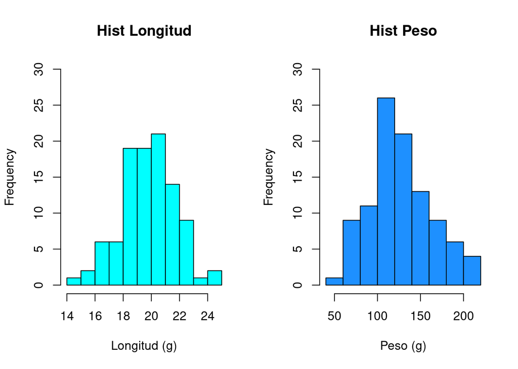

```r
# Promedio y varianza de la variable Longitud
Promedio_Longitud <- mean(Tilapia$Longitud_cm)
Var_Longitud <- var(Tilapia$Longitud_cm)

# Promedio y varianza de la variable Peso
Promedio_Peso <- mean(Tilapia$Peso_g)
Var_Peso <- var(Tilapia$Peso_g)

# Histogramas de las variables Longitud y Peso
par(mfrow = c(1,2))
hist(Tilapia$Longitud_cm, main= "Hist Longitud", xlab= "Longitud (g)", ylim= c(0,30),col="cyan")
hist(Tilapia$Peso_g, main= "Hist Peso", xlab= "Peso (g)", ylim= c(0,30),col="dodgerblue")
```

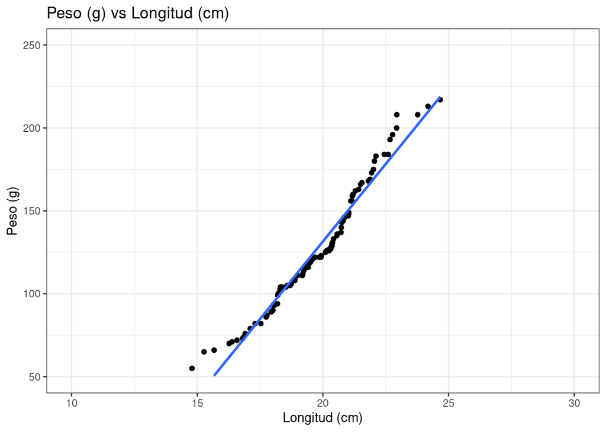

```r
# Gráfico de dispersión entre x e y
ggplot(Tilapia, aes(x=Tilapia$Longitud_cm, y=Tilapia$Peso_g))+
  geom_point()+
  ggtitle("Peso (g) vs Longitud (cm)") + geom_smooth(method=lm, se=FALSE)+
  scale_x_continuous(name = "Longitud (cm)", limits = c(10, 30), breaks = seq(10, 30, 5))+
  scale_y_continuous(name = "Peso (g)", limits = c(50,250), breaks = seq(50, 250, 50))+
  theme(plot.title = element_text(hjust = 0.5), panel.background = element_blank(), axis.line = element_line(color="black"), axis.line.x = element_line(color="black"))+
  theme_bw()
```

**c).** Calcule la correlación entre Longitud y Peso, use la función cor().

```r
cor(Tilapia$Longitud_cm,Tilapia$Peso_g)
```

```
## [1] 0.9827343
```

**d).** ¿Es está correlacción estadísticamente distinta de cero?. Escriba su hipótesis nula y alternativa para este experimento.

```r
# **H~0~**: $\rho$ = 0

# **H~1~**: $\rho$ $\ne$ 0
```

**e).** Realice una prueba de hipótesis para la correlación entre X e Y usando la función **cor.test()**, (llame al objeto cor_L_P) y obtenga los intervalos de confianza usando **cor.test()$conf.int** (llame a este objeto IC_cor_L_P) . Considere en **cor.test()** como nivel de confianza para la prueba el 95% y el método de Pearson. Para mostrar los resultados de la prueba de correlación usar la función **pander()** sobre el objeto **cor_L_P**, en el parámetro *caption* de la función **pander()** colocar “Prueba de hipótesis para el coeficiente de correlación entre Longitud y Peso.”.

```r
cor_L_P<- cor.test(x=Tilapia$Longitud_cm , y=Tilapia$Peso_g , method = "pearson", conf.level = 0.95)
cor_L_P
```

```
##
##  Pearson's product-moment correlation
##
## data:  Tilapia$Longitud_cm and Tilapia$Peso_g
## t = 52.581, df = 98, p-value < 2.2e-16
## alternative hypothesis: true correlation is not equal to 0
## 95 percent confidence interval:
##  0.9744019 0.9883704
## sample estimates:
##       cor
## 0.9827343
```

```r
IC_cor_L_P <-cor_L_P$conf.int
IC_cor_L_P
```

```
## [1] 0.9744019 0.9883704
## attr(,"conf.level")
## [1] 0.95
```

```r
pander::pander(cor_L_P, caption = "Prueba de hipótesis para el coeficiente de correlación entre Longitud y Peso.")
```

Prueba de hipótesis para el coeficiente de correlación entre Longitud y Peso.

| Test statistic | df | P value | Alternative hypothesis | cor |
| --- | --- | --- | --- | --- |
| 52.58 | 98 | 1.261e-73 * * * | two.sided | 0.9827 |

**f).** Interprete los resultados.

```r
# De los resultados obtenidos de la prueba, se observa que el p-valor= 1.261e-73 es menor al nivel de significación del 5%; concluyendo que hay evidencia estadísticamente significativa para rechazar H0. Por lo tanto, la correlación entre la longitud y el peso es distinta de cero.
```

### **Ejercicio 4.** **Prueba de hipótesis para la media**

Los datos **Salmones_Machos.xlsx** se refieren el peso (**Peso_g**) de 100 salmones machos del sur de chile.

**a).** Importe el set de datos **Salmones_Machos.xlsx** usando la función **read_excel()** de la librería **readxl**, llame al objeto Salmones_Machos. Explore el set de datos usando las funciones **head()**, **str()** y **summary()**.

```r
Salmones_Machos <- read_excel("Salmones_Machos.xlsx")
head(Salmones_Machos)
```

```
## # A tibble: 6 x 2
##      ID Peso_Machos
##   <dbl>       <dbl>
## 1     1        139
## 2     2        183.
## 3     3        128.
## 4     4        260.
## 5     5        191.
## 6     6        128.
```

```r
str(Salmones_Machos)
```

```
## tibble [100 × 2] (S3: tbl_df/tbl/data.frame)
##  $ ID         : num [1:100] 1 2 3 4 5 6 7 8 9 10 ...
##  $ Peso_Machos: num [1:100] 139 183 128 260 191 ...
```

```r
summary(Salmones_Machos)
```

```
##        ID          Peso_Machos
##  Min.   :  1.00   Min.   : 52.49
##  1st Qu.: 25.75   1st Qu.:146.20
##  Median : 50.50   Median :179.32
##  Mean   : 50.50   Mean   :179.05
##  3rd Qu.: 75.25   3rd Qu.:210.79
##  Max.   :100.00   Max.   :303.94
```

**b).** A partir del set de datos de **Salmones_Machos** elabore un histograma para la variable **Peso**. Use el comando **ggplot()** y el argumento **aes(x)**. Agregue el comando **geom_histogram()** para obtener el histograma y el comando **labs(x=“Peso (g)”,title=“Histograma de la variable Peso(g)”)**.

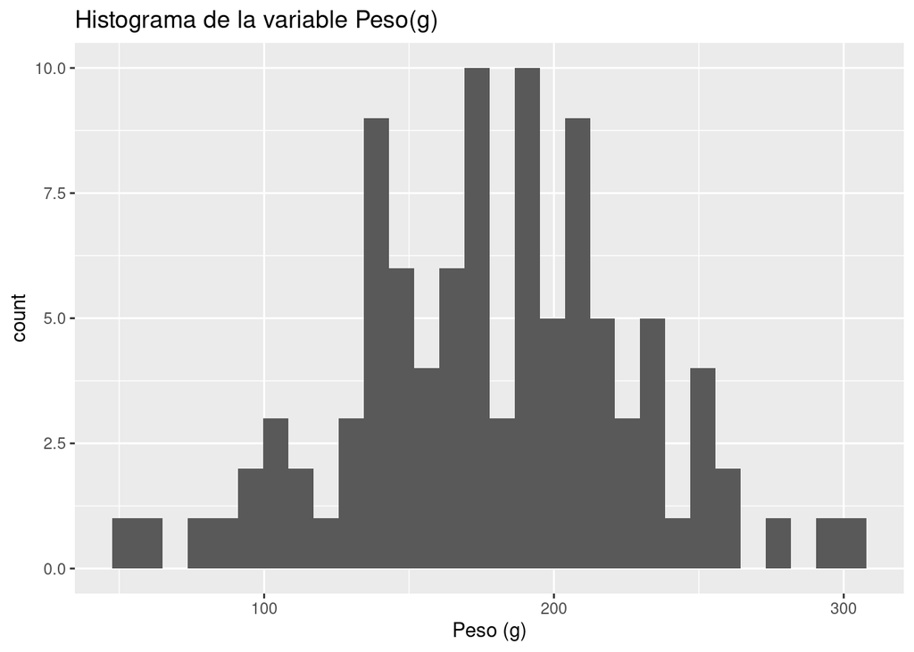

```r
Salmones_Machos %>%
  ggplot(aes(x=Peso_Machos))+
  geom_histogram()+
  labs(x="Peso (g)",title="Histograma de la variable Peso(g)")
```

**c).**Calcular la media y la varianza del peso de los machos.Luego,realice una tabla los estimadores puntuales del promedio y la varianza de la variable peso llamada Tabla_peso. Muestre la Tabla_peso en formato knitr::kable(), colocar en el parámetro **caption** “Media y varianza de salmones machos”.

```r
Tabla_Peso<- Salmones_Machos %>%
  summarize(Media_M = mean(Peso_Machos),
             Var_M = var(Peso_Machos))

# Tabla con los datos
knitr::kable(Tabla_Peso,caption ="Media y varianza de salmones machos")
```

Media y varianza de salmones machos

| Media_M | Var_M |
| --- | --- |
| 179.0507 | 2393.655 |

**d).** ¿El peso promedio de los machos es mayor a 190 (g)?. Escriba su hipótesis nula y alternativa para este experimento.

```r
# H~0~**: $$ \mu_{M} \le 190$$

# **H~1~**: **H~0~**: $$ \mu_{M} > 190$$
```

**e).** Realice una prueba de hipótesis para el peso promedio de los machos usando la función **t.test()**, (llame al objeto DifMed_M) y obtenga los intervalos de confianza usando **t.test()$conf.int** (llame a este objeto IC_DifMed_M) . Considere en **t.test** como nivel de confianza para la prueba el 95% y los parámetros, **alternative = c(“greater”)** y **mu = 190**. Para mostrar los resultados de la prueba de diferencia de medias usar la función **pander()** sobre el objeto **DifMed_M**, en el parámetro *caption* de la función **pander()** colocar “Prueba de hipótesis para el peso promedio de machos.”

```r
DifMed_M <- t.test(x=Salmones_Machos$Peso_Machos,mu = 190, alternative = c("greater"), conf.level = 0.95)
DifMed_M
```

```
##
##  One Sample t-test
##
## data:  Salmones_Machos$Peso_Machos
## t = -2.238, df = 99, p-value = 0.9863
## alternative hypothesis: true mean is greater than 190
## 95 percent confidence interval:
##  170.9272      Inf
## sample estimates:
## mean of x
##  179.0507
```

```r
IC_DifMed_M <-DifMed_M$conf.int
IC_DifMed_M
```

```
## [1] 170.9272      Inf
## attr(,"conf.level")
## [1] 0.95
```

```r
pander::pander(DifMed_M, caption = "Prueba de hipótesis para el peso promedio de machos")
```

Prueba de hipótesis para el peso promedio de machos

| Test statistic | df | P value | Alternative hypothesis | mean of x |
| --- | --- | --- | --- | --- |
| -2.238 | 99 | 0.9863 | greater | 179.1 |

**f).** Interprete los resultados.

```r
# De los resultados obtenidos de la prueba, se observa que el p-valor= 0.9863 es mayor al nivel de significación del 5%; concluyendo que no hay evidencia estadísticamente significativa para rechazar H0. Por lo tanto, el peso promedio de los machos es menor o igual a 190 (g).
```

### **Ejercicio 5.** **Prueba de hipótesis para la diferencia de medias con muestras independientes**

Los datos **Salmones_data.xlsx** se refieren el peso (**Peso_g**) de 100 salmones hembras y 100 salmones machos del sur de chile.

**a).** Importe el set de datos **Salmones_data.xlsx** usando la función **read_excel()** de la librería **readxl**, llame al objeto Salmones. Transforme la variable Sexo en factor con **as.factor()**. Explore el set de datos usando las funciones **head()**, **str()** y **summary()**.

```r
Salmones <- read_excel("Salmones_data.xlsx")
Salmones$Sexo <- as.factor(Salmones$Sexo)
head(Salmones)
```

```
## # A tibble: 6 x 3
##      ID  Peso Sexo
##   <dbl> <dbl> <fct>
## 1     1  139  Macho
## 2     2  183. Macho
## 3     3  128. Macho
## 4     4  260. Macho
## 5     5  191. Macho
## 6     6  128. Macho
```

```r
str(Salmones)
```

```
## tibble [200 × 3] (S3: tbl_df/tbl/data.frame)
##  $ ID  : num [1:200] 1 2 3 4 5 6 7 8 9 10 ...
##  $ Peso: num [1:200] 139 183 128 260 191 ...
##  $ Sexo: Factor w/ 2 levels "Hembra","Macho": 2 2 2 2 2 2 2 2 2 2 ...
```

```r
summary(Salmones)
```

```
##        ID              Peso            Sexo
##  Min.   :  1.00   Min.   : 52.49   Hembra:100
##  1st Qu.: 50.75   1st Qu.:141.01   Macho :100
##  Median :100.50   Median :170.82
##  Mean   :100.50   Mean   :175.33
##  3rd Qu.:150.25   3rd Qu.:206.51
##  Max.   :200.00   Max.   :303.94
```

**b).** A partir del set de datos de **Salmones** elabore un gráfico de cajas y bigotes para la variable **Peso**. Use el comando **ggplot()** y el argumento **aes(x,y,fill)** para seleccionar los datos, el factor **Sexo**, la variable respuesta **Peso** y el fill **Sexo**. Agregue el comando **geom_boxplot()** para obtener el boxplot y el comando **theme(legend.position=“none”)**. Además, adicione, el comando **labs(x=“Sexo”,y=“Peso (g)”,title=“Distribución entre las variables Peso vs Sexo (g)”)**.

Calcular la media y la varianza del peso de los machos como de la hembras.Luego, realice una tabla los estimadores puntuales de los promedios y las varianzas de la variable peso para cada sexo llamada Tabla. Muestre la Tabla en formato knitr::kable(), colocar en el parámetro **caption** “Medias y varianzas de salmones machos y hembras”.

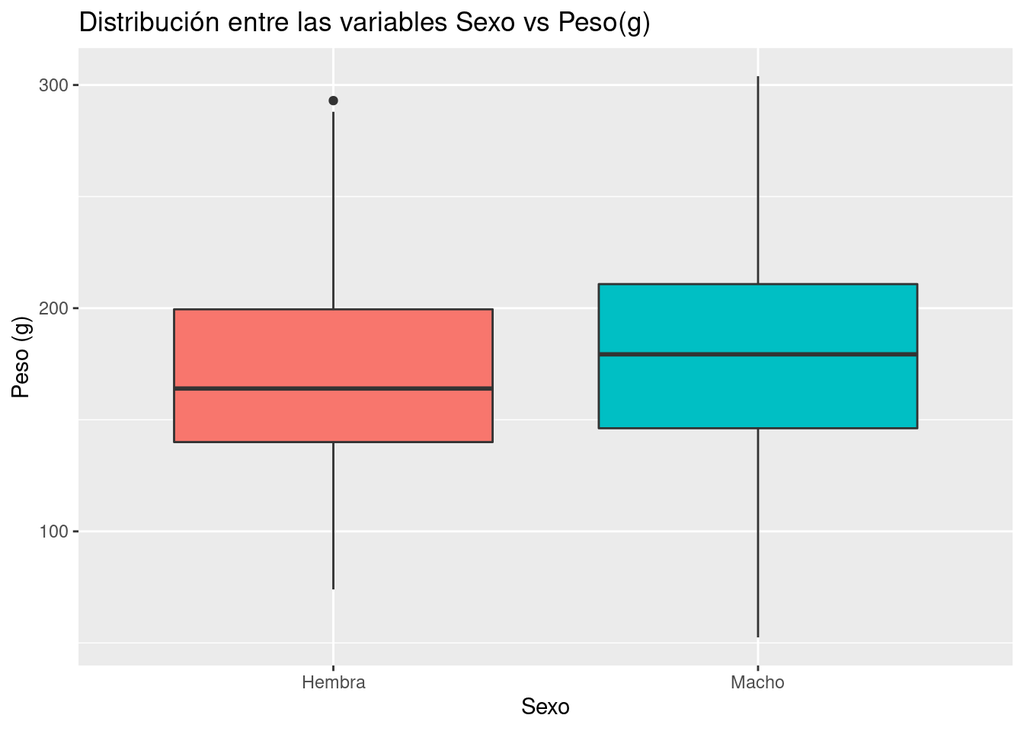

```r
Salmones%>%
  ggplot(aes(x=Sexo,y=Peso,fill=Sexo))+
      geom_boxplot()+
     theme(legend.position="none")+
     labs(x="Sexo",y="Peso (g)",title="Distribución entre las variables Sexo vs Peso(g)")
```

```r
Machos <- Salmones[Salmones$Sexo=="Macho", ]
Prome_Peso_Machos <- mean(Machos$Peso)
Var_Peso_Machos <- var(Machos$Peso)

Hembras <- Salmones[Salmones$Sexo=="Hembra", ]
Prome_Peso_Hembras <- mean(Hembras$Peso)
Var_Peso_Hembras <- var(Hembras$Peso)

Tabla <- data.frame(Prome_Peso_Machos, Var_Peso_Machos,Prome_Peso_Hembras,Var_Peso_Hembras )
colnames(Tabla) <- c("Peso Promedio Machos","Varianza_Peso_Machos", "Peso Promedio Hembras","Varianza_Peso_Hembras" )
# Tabla con los datos
knitr::kable(Tabla,caption ="Medias y varianzas de salmones machos y hembras")
```

Medias y varianzas de salmones machos y hembras

| Peso Promedio Machos | Varianza_Peso_Machos | Peso Promedio Hembras | Varianza_Peso_Hembras |
| --- | --- | --- | --- |
| 179.0507 | 2393.655 | 171.61 | 2459.23 |

**c).** Calcule la diferencia de los pesos promedio de los machos y las hembras.

```r
Dif_Med_M_H <- Prome_Peso_Machos - Prome_Peso_Hembras
```

**d).** ¿El peso promedio de los machos es diferente al peso promedio de las hembras?. Escriba su hipótesis nula y alternativa para este experimento.

```r
# **H~0~**: $$ \mu_{M} - \mu_{F} = 0$$

# **H~1~**: $$ \mu_{M} - \mu_{F} \ne 0$$
```

**e).** Realice una prueba de hipótesis para la diferencia de los pesos promedios de los machos y de las hembras usando la función **t.test()**, (llame al objeto DifMed_M_H) y obtenga los intervalos de confianza usando **t.test()$conf.int** (llame a este objeto IC_DifMed_M_H) . Considere en **t.test** como nivel de confianza para la prueba el 95% y los parámetros **paired=FALSE, var.equal=TRUE**. Para mostrar los resultados de la prueba de diferencia de medias usar la función **pander()** sobre el objeto **DifMed_M_H**, en el parámetro *caption* de la función **pander()** colocar “Prueba de hipótesis para la diferencia de pesos promedios entre machos y hembras.”

```r
Machos <- Salmones[Salmones$Sexo=="Macho", ]

Hembras <- Salmones[Salmones$Sexo=="Hembra", ]

DifMed_M_H<- t.test(x=Machos$Peso, y=Hembras$Peso,paired=FALSE, var.equal=TRUE,
       conf.level = 0.95)
DifMed_M_H
```

```
##
##  Two Sample t-test
##
## data:  Machos$Peso and Hembras$Peso
## t = 1.0681, df = 198, p-value = 0.2868
## alternative hypothesis: true difference in means is not equal to 0
## 95 percent confidence interval:
##  -6.296896 21.178296
## sample estimates:
## mean of x mean of y
##  179.0507  171.6100
```

```r
IC_DifMed_M_H <-DifMed_M_H$conf.int
IC_DifMed_M_H
```

```
## [1] -6.296896 21.178296
## attr(,"conf.level")
## [1] 0.95
```

```r
pander::pander(DifMed_M_H, caption = "Prueba de hipótesis para la diferencia de pesos promedios entre machos y hembras")
```

Prueba de hipótesis para la diferencia de pesos promedios entre machos y hembras

| Test statistic | df | P value | Alternative hypothesis | mean of x | mean of y |
| --- | --- | --- | --- | --- | --- |
| 1.068 | 198 | 0.2868 | two.sided | 179.1 | 171.6 |

**f).** Interprete los resultados.

```r
# De los resultados obtenidos de la prueba, se observa que el p-valor= 0.2868 es mayor al nivel de significación del 5%; concluyendo que no hay evidencia estadísticamente significativa para rechazar H0. Por lo tanto, los pesos promedios de machos y hembras son los mismos.
```